# Tutorial on Pivot Tables and other Excel things you can also do in R - Witch Trials data

## “Sort” data in R

*In Excel we can sort by columns.*

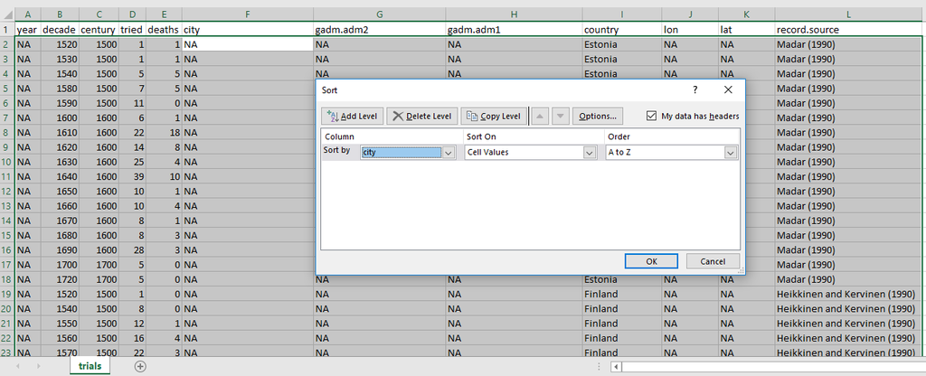

*Which functions can we use in R?*

R is different to Excel that we can also view data manipulations without assigning changes to an object. In these sorting examples we will just view the changes in-line.

```r
# Sort by character using arrange from dplyr. We can also pipe other packages functions such as head from the utils package.
witchdat %>%
  arrange(city) %>%
  head()
```

```
## # A tibble: 6 x 12
##    year decade century tried deaths city   gadm.adm2   gadm.adm1   country
##   <dbl>  <dbl>   <dbl> <dbl>  <dbl> <chr>  <chr>       <chr>       <chr>
## 1  1613   1610    1600     1     NA Aalen  Stuttgart   Baden-Wurt~ Germany
## 2  1564   1560    1500     1      0 Aalsm~ Aalsmeer    Noord-Holl~ Nether~
## 3  1596   1590    1500     1      1 Aalst  Oost-Vlaan~ Vlaanderen  Belgium
## 4  1601   1600    1600     1      1 Aalst  Oost-Vlaan~ Vlaanderen  Belgium
## 5  1658   1650    1600     1      0 Abbek~ Wognum      Noord-Holl~ Nether~
## 6  1499   1490    1400     1     NA Abens~ Mittelfran~ Bayern      Germany
## # ... with 3 more variables: lon <dbl>, lat <dbl>, record.source <chr>
```

```r
# This sorting also works on numeric variables, sort by year using arrange from dplyr
witchdat %>%
  arrange(year) %>%
  head()
```

```
## # A tibble: 6 x 12
##    year decade century tried deaths city   gadm.adm2  gadm.adm1   country
##   <dbl>  <dbl>   <dbl> <dbl>  <dbl> <chr>  <chr>      <chr>       <chr>
## 1  1300   1300    1300     1      0 Nurnb~ Mittelfra~ Bayern      Germany
## 2  1300   1300    1300     1     NA Freib~ Freiburg   Baden-Wurt~ Germany
## 3  1301   1300    1300     1      0 Coven~ West Midl~ England     United ~
## 4  1302   1300    1300     1      0 Exeter Devon      England     United ~
## 5  1302   1300    1300     1      0 Exeter Devon      England     United ~
## 6  1303   1300    1300     1      0 <NA>   <NA>       <NA>        France
## # ... with 3 more variables: lon <dbl>, lat <dbl>, record.source <chr>
```

```r
# Or we can sort in descending order
witchdat %>%
  arrange(desc(year)) %>%
  head()
```

```
## # A tibble: 6 x 12
##    year decade century tried deaths city     gadm.adm2  gadm.adm1  country
##   <dbl>  <dbl>   <dbl> <dbl>  <dbl> <chr>    <chr>      <chr>      <chr>
## 1  1850   1850    1800     1      0 Vrouwen~ Veere      Zeeland    Nether~
## 2  1835   1830    1800     1      0 Sint-An~ Tholen     Zeeland    Nether~
## 3  1826   1820    1800     1      0 Amsterd~ Amsterdam  Noord-Hol~ Nether~
## 4  1792   1790    1700     1     NA Dinkels~ Mittelfra~ Bayern     Germany
## 5  1790   1790    1700     1     NA Memming~ Mittelfra~ Bayern     Germany
## 6  1790   1790    1700     1      0 <NA>     <NA>       Sachsen    Germany
## # ... with 3 more variables: lon <dbl>, lat <dbl>, record.source <chr>
```

## Create a “formula” in R

*In Excel we can create formulas in cells.*

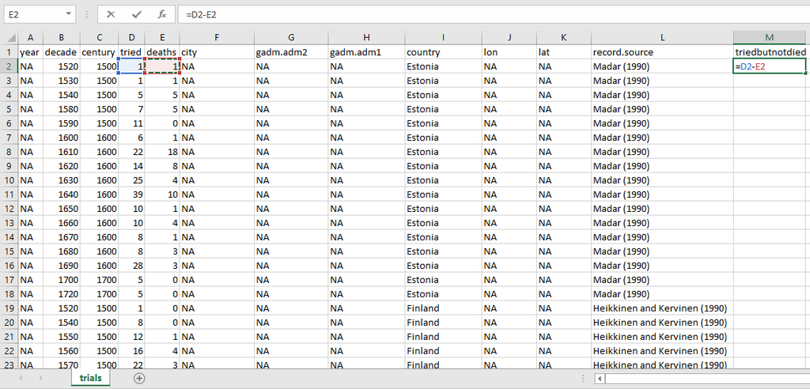

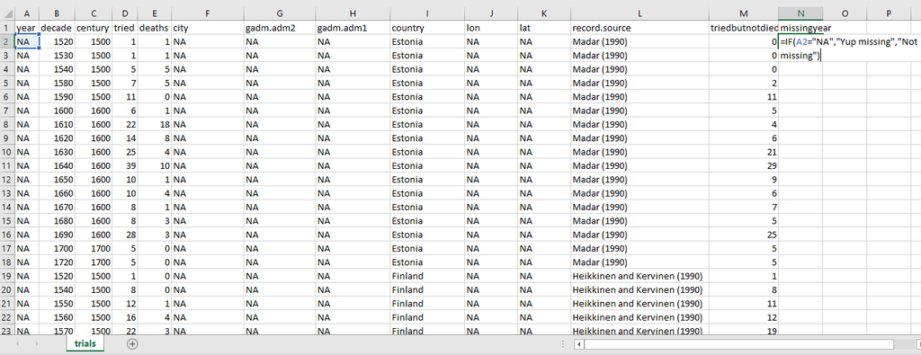

*Which functions can we use in R?*

```r
# Remember R as a calculator? This is a simple formula
3+2
```

```
## [1] 5
```

```r
# Create a new variable in our dataframe called triedbutnotdied as the difference between two variables (formula after the =). Use the mutate function from dplyr
witchdat <- witchdat %>%
  mutate(triedbutnotdied = tried-deaths)
```

```r
# In R missing values are typically NA values. A handy base function to know is is.na(). Try typing ?is.na in the console.  Let's use this function in a new formula to test if a variable is populated
witchdat <- witchdat %>%
  mutate(missingyear = ifelse(is.na(year),"Yup missing","Not missing"))
# View the structure of witchdat again to see these new variables
glimpse(witchdat)
```

```
## Observations: 10,940
## Variables: 14
## $ year            <dbl> NA, NA, NA, NA, NA, NA, NA, NA, NA, NA, NA, NA...
## $ decade          <dbl> 1520, 1530, 1540, 1580, 1590, 1600, 1610, 1620...
## $ century         <dbl> 1500, 1500, 1500, 1500, 1500, 1600, 1600, 1600...
## $ tried           <dbl> 1, 1, 5, 7, 11, 6, 22, 14, 25, 39, 10, 10, 8, ...
## $ deaths          <dbl> 1, 1, 5, 5, 0, 1, 18, 8, 4, 10, 1, 4, 1, 3, 3,...
## $ city            <chr> NA, NA, NA, NA, NA, NA, NA, NA, NA, NA, NA, NA...
## $ gadm.adm2       <chr> NA, NA, NA, NA, NA, NA, NA, NA, NA, NA, NA, NA...
## $ gadm.adm1       <chr> NA, NA, NA, NA, NA, NA, NA, NA, NA, NA, NA, NA...
## $ country         <chr> "Estonia", "Estonia", "Estonia", "Estonia", "E...
## $ lon             <dbl> NA, NA, NA, NA, NA, NA, NA, NA, NA, NA, NA, NA...
## $ lat             <dbl> NA, NA, NA, NA, NA, NA, NA, NA, NA, NA, NA, NA...
## $ record.source   <chr> "Madar (1990)", "Madar (1990)", "Madar (1990)"...
## $ triedbutnotdied <dbl> 0, 0, 0, 2, 11, 5, 4, 6, 21, 29, 9, 6, 7, 5, 2...
## $ missingyear     <chr> "Yup missing", "Yup missing", "Yup missing", "...
```

## Filter a “column”

*In Excel we can filter by columns.*

[figure not shown]

*Which functions can we use in R?*

```r
# Filter which witches were tried in decade 1520 by using dplyr filter. Remember to use == for equals in R, whereas = is an assignment operator in R functions.
witchdat %>%
  filter(decade==1520) %>%
  head()
```

```
## # A tibble: 6 x 14
##    year decade century tried deaths city  gadm.adm2 gadm.adm1   country
##   <dbl>  <dbl>   <dbl> <dbl>  <dbl> <chr> <chr>     <chr>       <chr>
## 1    NA   1520    1500     1      1 <NA>  <NA>      <NA>        Estonia
## 2    NA   1520    1500     1      0 <NA>  <NA>      <NA>        Finland
## 3    NA   1520    1500     3      1 <NA>  <NA>      <NA>        Hungary
## 4    NA   1520    1500     2      1 <NA>  <NA>      Basel-Stadt Switzerla~
## 5    NA   1520    1500     2      2 <NA>  <NA>      Bern        Switzerla~
## 6    NA   1520    1500     4      4 <NA>  <NA>      Fribourg    Switzerla~
## # ... with 5 more variables: lon <dbl>, lat <dbl>, record.source <chr>,
## #   triedbutnotdied <dbl>, missingyear <chr>
```

## Calculate on “columns”

*In Excel we can add a calculation such as sum or a mean to a column.*

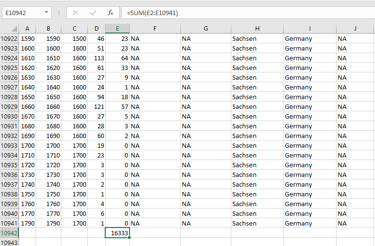

*Which functions can we use in R?*

In R Markdown documents we can “highlight” and comment on insights, calculations or data manipulations.

```r
# Sum the total deaths. Remember there are NA values so we need to tell this sum function to ignore these with argument na.rm=TRUE. Using sum on the 'whole column' ie variable witchdat$deaths is intuitively the same way of calculating this sum in Excel
sum(witchdat$deaths,na.rm=TRUE)
```

```
## [1] 16333
```

```r
# Now use dplyr with the select function to select the deaths variable (also the same as deleting the other columns in Excel) then apply the sum on this object
witchdat %>%
  select(deaths) %>%
  sum(na.rm = TRUE)
```

```
## [1] 16333
```

```r
# Now try the dplyr summarise function and sum function then name this sum object as sum_deaths
witchdat %>%
  summarise(sum_deaths = sum(deaths, na.rm = TRUE))
```

```
## # A tibble: 1 x 1
##   sum_deaths
##        <dbl>
## 1      16333
```

## Create a “Pivot Table”

*In Excel you can create pivot tables.*

[figure not shown]

*Which functions can we use in R?*

In R we can use the table function to create a simple pivot table.

```r
# Use th table function to find a simple count by country
witchdat %>%
  select(country) %>%
      table()
```

```
## .
##        Austria        Belgium Czech Republic        Denmark        Estonia
##             16            671              1             90             17
##        Finland         France        Germany        Hungary        Ireland
##             17            807           3417             26              4
##          Italy     Luxembourg    Netherlands         Norway         Poland
##            107             20            314             20              9
##          Spain         Sweden    Switzerland United Kingdom
##             29            353           1272           3750
```

A neat R package that creates interactive pivot tables is [rpivotTable](https://cran.r-project.org/web/packages/rpivotTable/). Have a look at this package’s [vignette](https://cran.r-project.org/web/packages/rpivotTable/vignettes/rpivotTableIntroduction.html).

This example shows the sum of the “witches”" tried by country.

```r
# Create an interactive pivot table using the rpivotTable function and package.
rpivotTable(witchdat,rows="country",vals="tried",aggregator="Sum")
```

[interactive table not shown]

**Challenge 1** Can you recreate the pivot table as a new R data frame using `dplyr` functions? (Hint ?group_by)

**Challenge 2** On the pivot table widget move the `country` above the table so the `country` is a pivot table column. Can you extend your challenge 1 answer with `dplyr` to recreate.

**Challenge 3** On the pivot table widget move `decade` and `country` as pivot table rows. Can you extend your challenge 1 answer with `dplyr` to recreate.

## Save the “spreadsheet”

*In Excel you can save your workbooks and spreadsheets. Which functions can we use in R?*

Here are some options in R, depending on what output is needed:

- The `base` R `write.csv` function to write to a csv file
- The `readr` package in the tidyverse, includes the function `write_csv`, which is faster than write.csv
- The `xlsx` package `write.xlsx` to write to an Excel workbook

```r
# Save dataframe with write_csv from readr package
write_csv(witchdat,"witchdat.csv")
```

## Acknowledgments

Thanks to Marcia Ferreira @DrMarciaFe, Chris Beltz @BeltzEcology, Duncan Garmonsway @nacnudus and Ivan Leung @urganmax for reviewing and providing suggestions on this tutorial through Twitter.